# Convolutional Neural Network -- Labeled Faces in the Wild Database

## Team 1: Shou-An Cheng, Jiaqi Fan, Chen Liu, Dan Liu, Chang Wen, Zhenghao Xiao

Database: http://vis-www.cs.umass.edu/lfw/index.html

We use CNN to deal with this task.

- Working environment: MacOS + ANACONDA + Jupyter Notebook + Python3.7
- Loading the LFW data using the fuel library: https://fuel.readthedocs.io/en/latest/index.html
- LFW_Fuel Package: https://github.com/dribnet/lfw_fuel

## Environment Setup

```python
import os
os.environ['KMP_DUPLICATE_LIB_OK']='True'
DATASETS_FOLDER = 'datasets'
if not os.path.isdir(DATASETS_FOLDER):
    os.mkdir(DATASETS_FOLDER)
    os.environ['FUEL_DATA_PATH']='./datasets/'
```

```python
import numpy as np
np.random.seed(7100)  # for reproducibility

import warnings
warnings.filterwarnings('ignore',category=FutureWarning)
import tensorflow as tf

from tensorflow import keras
from tensorflow.keras.models import Sequential
from tensorflow.keras.layers import Dense, Dropout, Activation, Flatten
from tensorflow.keras.layers import Conv2D, MaxPooling2D, MaxPooling3D, AveragePooling2D
from tensorflow.keras.constraints import MaxNorm
from tensorflow.keras.optimizers import SGD
from tensorflow.keras import utils

from skimage.transform import resize
import matplotlib.pylab as plt
from lfw_fuel import lfw
```

## Crop and downsample function

```python
def crop_and_downsample(originalX, downsample_size=32):
    """
    Starts with a 250 x 250 image.
    Crops to 128 x 128 around the center.
    Downsamples the image to (downsample_size) x (downsample_size).
    Returns an image with dimensions (channel, width, height).
    """
    current_dim = 250
    target_dim = 128
    margin = int((current_dim - target_dim)/2)
    left_margin = margin
    right_margin = current_dim - margin

    # newim is shape (6, 128, 128)
    newim = originalX[:, left_margin:right_margin, left_margin:right_margin]

    # This transpose is mainly useful for plotting with color:
    # Put the images in standard dimension order
    # (width, height, channels)
    sized1 = newim[0:3,:,:]
    sized1 = np.transpose(sized1,(1,2,0))

    sized2 = newim[3:6,:,:]
    sized2 = np.transpose(sized2,(1,2,0))

    # resized are shape (feature_width, feature_height, 3)
    feature_width = feature_height = downsample_size
    resized1 = resize(sized1, (feature_width, feature_height), order=3, anti_aliasing=True)
    resized2 = resize(sized2, (feature_width, feature_height), order=3, anti_aliasing=True)

    # re-packge into a new X entry
    newX = np.concatenate([resized1,resized2], axis=2)

    return newX

a = 0
```

## Load the data from LFW web

There are three dataset options:

```
* Original
* Funneling
* Deep Funneling
```

We choose Deep Funneling dataset

```python
# Load the data, shuffled and split between train and test sets
(X_train_original, y_train_original), (X_test_original, y_test_original) = lfw.load_data("deepfunneled")
```

## Transform raw pictures

```python
# Start with 32*32 picture size
ds = 32
X_train = np.asarray([crop_and_downsample(x, downsample_size=ds) for x in X_train_original])
X_test  = np.asarray([crop_and_downsample(x, downsample_size=ds) for x in X_test_original])
y_train = y_train_original
y_test  = y_test_original
```

## Check Individual Datapoint

Make sure we read the data in correctly

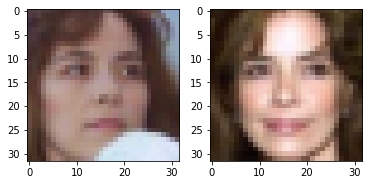

```python
# datapoint 1
fig = plt.figure()
ax1, ax2 = [fig.add_subplot(1,2,i+1) for i in range(2)]
ax1.imshow(X_train[6,:,:,0:3])
ax2.imshow(X_train[6,:,:,3:6])
plt.show()
```

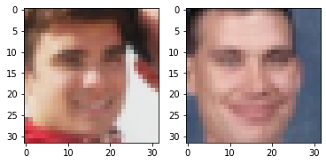

```python
# datapoint 2
fig = plt.figure()
ax1, ax2 = [fig.add_subplot(1,2,i+1) for i in range(2)]
ax1.imshow(X_test[12,:,:,0:3])
ax2.imshow(X_test[12,:,:,3:6])
plt.show()
```

```python
print(y_train.shape)
print("Zeros: %d"%(np.sum(y_train==0)))
print("Ones: %d"%(np.sum(y_train==1)))
```

```
(2200, 1)
Zeros: 1100
Ones: 1100
```

## Build Baseline Model

- Input
- Conv1: 32 feature, 3*3 kernel size
- Conv2: 64 feature, 3*3 kernel size
- Pooling1: 2*2
- Dropout1: 0.2
- FullConnect
- Dropout2: 0.5
- Output

```python
# Baseline Model

base_model = Sequential()

# Input and first convolutional layer
base_model.add(Conv2D(32, (3,3),
                  input_shape=(ds,ds,6),
                  padding='same',
                  data_format='channels_last',
                  activation='relu'))

# Second convolutional layer
base_model.add(Conv2D(64, (3,3),
                  padding='same',
                  data_format='channels_last',
                  activation='relu'))

# Pooling layer 1
base_model.add(AveragePooling2D(pool_size=(2,2),
                            data_format='channels_last'))

# Dropout after pooling 1
base_model.add(Dropout(0.2))

# Flatten layer.
base_model.add(Flatten())

# Fully connected layer
base_model.add(Dense(128, activation='relu',kernel_constraint=MaxNorm(3)))

# Dropout set to 50%.
base_model.add(Dropout(0.5))

# Output layer with 2 units (Y/N) (sigmoid activation function)
base_model.add(Dense(1, activation='sigmoid'))

print(base_model.summary())
```

```
WARNING:tensorflow:From /Users/nosam/anaconda3/lib/python3.7/site-packages/tensorflow/python/ops/init_ops.py:1251: calling VarianceScaling.__init__ (from tensorflow.python.ops.init_ops) with dtype is deprecated and will be removed in a future version.
Instructions for updating:
Call initializer instance with the dtype argument instead of passing it to the constructor
Model: "sequential"
_________________________________________________________________
Layer (type)                 Output Shape              Param #
=================================================================
conv2d (Conv2D)              (None, 32, 32, 32)        1760
_________________________________________________________________
conv2d_1 (Conv2D)            (None, 32, 32, 64)        18496
_________________________________________________________________
average_pooling2d (AveragePo (None, 16, 16, 64)        0
_________________________________________________________________
dropout (Dropout)            (None, 16, 16, 64)        0
_________________________________________________________________
flatten (Flatten)            (None, 16384)             0
_________________________________________________________________
dense (Dense)                (None, 128)               2097280
_________________________________________________________________
dropout_1 (Dropout)          (None, 128)               0
_________________________________________________________________
dense_1 (Dense)              (None, 1)                 129
=================================================================
Total params: 2,117,665
Trainable params: 2,117,665
Non-trainable params: 0
_________________________________________________________________
None
```

```python
# Compile model:
base_model.compile(loss='binary_crossentropy', optimizer='adam', metrics=['binary_accuracy'])
```

[output not shown]

```python
epochs = 25
batch_size = 128

base_CNN = base_model.fit(X_train, y_train,
           batch_size=batch_size,
           epochs=epochs,
           verbose=1,
           validation_data=(X_test, y_test))
```

```
Train on 2200 samples, validate on 1000 samples
```

```python
res1 = base_model.predict(X_train)
res2 = base_model.predict(X_test)
```

```python
print("Training Data:")
print("Zeros: %d"%(np.sum(res1<0.5)))
print("Ones: %d"%(np.sum(res1>0.5)))
print("\n")
print("Testing Data:")
print("Zeros: %d"%(np.sum(res2<0.5)))
print("Ones: %d"%(np.sum(res2>0.5)))
```

```
Training Data:
Zeros: 1116
Ones: 1084


Testing Data:
Zeros: 527
Ones: 473
```

```python
score = base_model.evaluate(X_test, y_test, verbose=0)
print('Baseline Test accuracy: {0:%}'.format(score[1]))
```

```
Baseline Test accuracy: 70.300001%
```

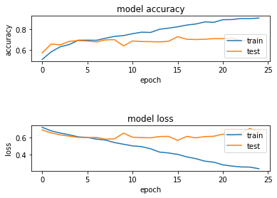

```python
plt.subplot(3,1,1)
plt.plot(base_CNN.history['binary_accuracy'])
plt.plot(base_CNN.history['val_binary_accuracy'])
plt.title('model accuracy')
plt.ylabel('accuracy')
plt.xlabel('epoch')
plt.legend(['train', 'test'], loc='lower right')

plt.subplot(3,1,3)
plt.plot(base_CNN.history['loss'])
plt.plot(base_CNN.history['val_loss'])
plt.title('model loss')
plt.ylabel('loss')
plt.xlabel('epoch')
plt.legend(['train', 'test'], loc='upper right')

plt.show()
```

## Model A

kernel size: 5*5

```python
modelA = Sequential()

# Input and first convolutional layer
modelA.add(Conv2D(32, (5,5),
                  input_shape=(ds,ds,6),
                  padding='same',
                  data_format='channels_last',
                  activation='relu'))

# Second convolutional layer
modelA.add(Conv2D(64, (5,5),
                  padding='same',
                  data_format='channels_last',
                  activation='relu'))

# Pooling layer 1
modelA.add(AveragePooling2D(pool_size=(2,2),
                            data_format='channels_last'))

# Dropout after pooling 1
modelA.add(Dropout(0.2))

# Flatten layer.
modelA.add(Flatten())

# Fully connected layer
modelA.add(Dense(128, activation='relu',kernel_constraint=MaxNorm(3)))

# Dropout set to 50%.
modelA.add(Dropout(0.5))

# Output layer with 2 units (Y/N) (sigmoid activation function)
modelA.add(Dense(1, activation='sigmoid'))

print(modelA.summary())
```

```
Model: "sequential_1"
_________________________________________________________________
Layer (type)                 Output Shape              Param #
=================================================================
conv2d_2 (Conv2D)            (None, 32, 32, 32)        4832
_________________________________________________________________
conv2d_3 (Conv2D)            (None, 32, 32, 64)        51264
_________________________________________________________________
average_pooling2d_1 (Average (None, 16, 16, 64)        0
_________________________________________________________________
dropout_2 (Dropout)          (None, 16, 16, 64)        0
_________________________________________________________________
flatten_1 (Flatten)          (None, 16384)             0
_________________________________________________________________
dense_2 (Dense)              (None, 128)               2097280
_________________________________________________________________
dropout_3 (Dropout)          (None, 128)               0
_________________________________________________________________
dense_3 (Dense)              (None, 1)                 129
=================================================================
Total params: 2,153,505
Trainable params: 2,153,505
Non-trainable params: 0
_________________________________________________________________
None
```

```python
# Compile model:
modelA.compile(loss='binary_crossentropy', optimizer='adam', metrics=['binary_accuracy'])
```

```python
epochs = 25
batch_size = 128

modelA_CNN = modelA.fit(X_train, y_train,
           batch_size=batch_size,
           epochs=epochs,
           verbose=1,
           validation_data=(X_test, y_test))
```

```
Train on 2200 samples, validate on 1000 samples
```

```python
res1 = modelA.predict(X_train)
res2 = modelA.predict(X_test)
```

```python
print("Training Data:")
print("Zeros: %d"%(np.sum(res1<0.5)))
print("Ones: %d"%(np.sum(res1>0.5)))
print("\n")
print("Testing Data:")
print("Zeros: %d"%(np.sum(res2<0.5)))
print("Ones: %d"%(np.sum(res2>0.5)))
```

```
Training Data:
Zeros: 1095
Ones: 1105


Testing Data:
Zeros: 534
Ones: 466
```

```python
score = modelA.evaluate(X_test, y_test, verbose=0)
print('modelA Test accuracy: {0:%}'.format(score[1]))
```

```
modelA Test accuracy: 69.999999%
```

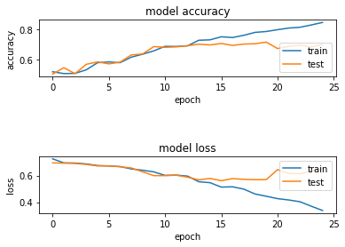

```python
plt.subplot(3,1,1)
plt.plot(modelA_CNN.history['binary_accuracy'])
plt.plot(modelA_CNN.history['val_binary_accuracy'])
plt.title('model accuracy')
plt.ylabel('accuracy')
plt.xlabel('epoch')
plt.legend(['train', 'test'], loc='lower right')

plt.subplot(3,1,3)
plt.plot(modelA_CNN.history['loss'])
plt.plot(modelA_CNN.history['val_loss'])
plt.title('model loss')
plt.ylabel('loss')
plt.xlabel('epoch')
plt.legend(['train', 'test'], loc='upper right')

plt.show()
```

## Model B

kernel size: 7*7

```python
modelB = Sequential()

# Input and first convolutional layer
modelB.add(Conv2D(32, (7,7),
                  input_shape=(ds,ds,6),
                  padding='same',
                  data_format='channels_last',
                  activation='relu'))

# Second convolutional layer
modelB.add(Conv2D(64, (7,7),
                  padding='same',
                  data_format='channels_last',
                  activation='relu'))

# Pooling layer 1
modelB.add(AveragePooling2D(pool_size=(2,2),
                            data_format='channels_last'))

# Dropout after pooling 1
modelB.add(Dropout(0.2))

# Flatten layer.
modelB.add(Flatten())

# Fully connected layer
modelB.add(Dense(128, activation='relu',kernel_constraint=MaxNorm(3)))

# Dropout set to 50%.
modelB.add(Dropout(0.5))

# Output layer with 2 units (Y/N) (sigmoid activation function)
modelB.add(Dense(1, activation='sigmoid'))

print(modelB.summary())
```

```
Model: "sequential_2"
_________________________________________________________________
Layer (type)                 Output Shape              Param #
=================================================================
conv2d_4 (Conv2D)            (None, 32, 32, 32)        9440
_________________________________________________________________
conv2d_5 (Conv2D)            (None, 32, 32, 64)        100416
_________________________________________________________________
average_pooling2d_2 (Average (None, 16, 16, 64)        0
_________________________________________________________________
dropout_4 (Dropout)          (None, 16, 16, 64)        0
_________________________________________________________________
flatten_2 (Flatten)          (None, 16384)             0
_________________________________________________________________
dense_4 (Dense)              (None, 128)               2097280
_________________________________________________________________
dropout_5 (Dropout)          (None, 128)               0
_________________________________________________________________
dense_5 (Dense)              (None, 1)                 129
=================================================================
Total params: 2,207,265
Trainable params: 2,207,265
Non-trainable params: 0
_________________________________________________________________
None
```

```python
# Compile model:
modelB.compile(loss='binary_crossentropy', optimizer='adam', metrics=['binary_accuracy'])
```

```python
epochs = 25
batch_size = 128

modelB_CNN = modelB.fit(X_train, y_train,
           batch_size=batch_size,
           epochs=epochs,
           verbose=1,
           validation_data=(X_test, y_test))
```

```
Train on 2200 samples, validate on 1000 samples
```

```python
res1 = modelB.predict(X_train)
res2 = modelB.predict(X_test)
```

```python
print("Training Data:")
print("Zeros: %d"%(np.sum(res1<0.5)))
print("Ones: %d"%(np.sum(res1>0.5)))
print("\n")
print("Testing Data:")
print("Zeros: %d"%(np.sum(res2<0.5)))
print("Ones: %d"%(np.sum(res2>0.5)))
```

```
Training Data:
Zeros: 1167
Ones: 1033


Testing Data:
Zeros: 598
Ones: 402
```

```python
score = modelB.evaluate(X_test, y_test, verbose=0)
print('modelB Test accuracy: {0:%}'.format(score[1]))
```

```
modelB Test accuracy: 70.400000%
```

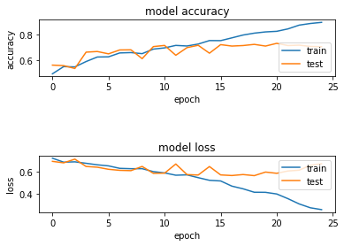

```python
plt.subplot(3,1,1)
plt.plot(modelB_CNN.history['binary_accuracy'])
plt.plot(modelB_CNN.history['val_binary_accuracy'])
plt.title('model accuracy')
plt.ylabel('accuracy')
plt.xlabel('epoch')
plt.legend(['train', 'test'], loc='lower right')

plt.subplot(3,1,3)
plt.plot(modelB_CNN.history['loss'])
plt.plot(modelB_CNN.history['val_loss'])
plt.title('model loss')
plt.ylabel('loss')
plt.xlabel('epoch')
plt.legend(['train', 'test'], loc='upper right')

plt.show()
```

## Build More Complex Model

Model C:

- Input
- Conv1: 32 feature, 5*5 kernel size
- Conv2: 64 feature, 5*5 kernel size
- Pooling1: 2*2
- Dropout1: 0.2
- Conv3: 128 feature, 5*5 kernel size
- Pooling2: 2*2
- Dropout2: 0.2
- FullConnect
- Dropout3: 0.5
- Output

```python
# modelC

modelC = Sequential()

# Input and first convolutional layer
modelC.add(Conv2D(32, (5,5),
                  input_shape=(ds,ds,6),
                  padding='same',
                  data_format='channels_last',
                  activation='relu'))

# Second convolutional layer
modelC.add(Conv2D(64, (5,5),
                  padding='same',
                  data_format='channels_last',
                  activation='relu'))

# Pooling layer 1
modelC.add(AveragePooling2D(pool_size=(2,2),
                            data_format='channels_last'))

# Dropout after pooling 1
modelC.add(Dropout(0.2))

# Third convolutional layer
modelC.add(Conv2D(128, (5,5),
                  padding='same',
                  data_format='channels_last',
                  activation='relu'))

# Pooling layer 2
modelC.add(AveragePooling2D(pool_size=(2,2),
                            data_format='channels_last'))

# Dropout after pooling 2
modelC.add(Dropout(0.2))

# Flatten layer.
modelC.add(Flatten())

# Fully connected layer
modelC.add(Dense(128, activation='relu',kernel_constraint=MaxNorm(3)))

# Dropout set to 50%.
modelC.add(Dropout(0.5))

# Output layer with 2 units (Y/N) (sigmoid activation function)
modelC.add(Dense(1, activation='sigmoid'))

print(modelC.summary())
```

```
Model: "sequential_3"
_________________________________________________________________
Layer (type)                 Output Shape              Param #
=================================================================
conv2d_6 (Conv2D)            (None, 32, 32, 32)        4832
_________________________________________________________________
conv2d_7 (Conv2D)            (None, 32, 32, 64)        51264
_________________________________________________________________
average_pooling2d_3 (Average (None, 16, 16, 64)        0
_________________________________________________________________
dropout_6 (Dropout)          (None, 16, 16, 64)        0
_________________________________________________________________
conv2d_8 (Conv2D)            (None, 16, 16, 128)       204928
_________________________________________________________________
average_pooling2d_4 (Average (None, 8, 8, 128)         0
_________________________________________________________________
dropout_7 (Dropout)          (None, 8, 8, 128)         0
_________________________________________________________________
flatten_3 (Flatten)          (None, 8192)              0
_________________________________________________________________
dense_6 (Dense)              (None, 128)               1048704
_________________________________________________________________
dropout_8 (Dropout)          (None, 128)               0
_________________________________________________________________
dense_7 (Dense)              (None, 1)                 129
=================================================================
Total params: 1,309,857
Trainable params: 1,309,857
Non-trainable params: 0
_________________________________________________________________
None
```

```python
# Compile model:
modelC.compile(loss='binary_crossentropy', optimizer='adam', metrics=['binary_accuracy'])
```

```python
epochs = 25
batch_size = 128

modelC_CNN = modelC.fit(X_train, y_train,
           batch_size=batch_size,
           epochs=epochs,
           verbose=1,
           validation_data=(X_test, y_test))
```

```
Train on 2200 samples, validate on 1000 samples
```

```python
res1 = modelC.predict(X_train)
res2 = modelC.predict(X_test)
```

```python
print("Training Data:")
print("Zeros: %d"%(np.sum(res1<0.5)))
print("Ones: %d"%(np.sum(res1>0.5)))
print("\n")
print("Testing Data:")
print("Zeros: %d"%(np.sum(res2<0.5)))
print("Ones: %d"%(np.sum(res2>0.5)))
```

```
Training Data:
Zeros: 1235
Ones: 965


Testing Data:
Zeros: 584
Ones: 416
```

```python
score = modelC.evaluate(X_test, y_test, verbose=0)
print('modelC Test accuracy: {0:%}'.format(score[1]))
```

```
modelC Test accuracy: 69.999999%
```

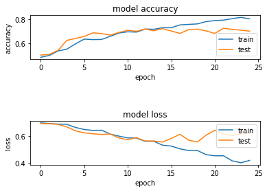

```python
plt.subplot(3,1,1)
plt.plot(modelC_CNN.history['binary_accuracy'])
plt.plot(modelC_CNN.history['val_binary_accuracy'])
plt.title('model accuracy')
plt.ylabel('accuracy')
plt.xlabel('epoch')
plt.legend(['train', 'test'], loc='lower right')

plt.subplot(3,1,3)
plt.plot(modelC_CNN.history['loss'])
plt.plot(modelC_CNN.history['val_loss'])
plt.title('model loss')
plt.ylabel('loss')
plt.xlabel('epoch')
plt.legend(['train', 'test'], loc='upper right')

plt.show()
```

## Final Best Model

```python
from tensorflow.keras.callbacks import ModelCheckpoint
# Define a checkpoint to save the data
checkpoint_name = 'weights.best.hdf5'
checkpoint = ModelCheckpoint(checkpoint_name, monitor='val_binary_accuracy', verbose = 1, save_best_only = True, mode ='max')
callbacks_list = [checkpoint]
```

```python
# Train the model
final_CNN = modelC.fit(X_train, y_train,
           batch_size=128,
           epochs=100,
           verbose=1,
           validation_data=(X_test, y_test),
           callbacks=callbacks_list)
```

```
Train on 2200 samples, validate on 1000 samples
Epoch 00001: val_binary_accuracy improved from -inf to 0.69400, saving model to weights.best.hdf5
Epoch 00002: val_binary_accuracy improved from 0.69400 to 0.71200, saving model to weights.best.hdf5
Epoch 00003: val_binary_accuracy did not improve from 0.71200
Epoch 00004: val_binary_accuracy did not improve from 0.71200
Epoch 00005: val_binary_accuracy did not improve from 0.71200
Epoch 00006: val_binary_accuracy did not improve from 0.71200
Epoch 00007: val_binary_accuracy did not improve from 0.71200
Epoch 00008: val_binary_accuracy improved from 0.71200 to 0.72100, saving model to weights.best.hdf5
Epoch 00009: val_binary_accuracy did not improve from 0.72100
Epoch 00010: val_binary_accuracy did not improve from 0.72100
Epoch 00011: val_binary_accuracy did not improve from 0.72100
Epoch 00012: val_binary_accuracy did not improve from 0.72100
Epoch 00013: val_binary_accuracy did not improve from 0.72100
Epoch 00014: val_binary_accuracy did not improve from 0.72100
Epoch 00015: val_binary_accuracy did not improve from 0.72100
Epoch 00016: val_binary_accuracy did not improve from 0.72100
Epoch 00017: val_binary_accuracy did not improve from 0.72100
Epoch 00018: val_binary_accuracy did not improve from 0.72100
Epoch 00019: val_binary_accuracy did not improve from 0.72100
Epoch 00020: val_binary_accuracy did not improve from 0.72100
Epoch 00021: val_binary_accuracy did not improve from 0.72100
Epoch 00022: val_binary_accuracy did not improve from 0.72100
Epoch 00023: val_binary_accuracy did not improve from 0.72100
Epoch 00024: val_binary_accuracy did not improve from 0.72100
Epoch 00025: val_binary_accuracy did not improve from 0.72100
Epoch 00026: val_binary_accuracy did not improve from 0.72100
Epoch 00027: val_binary_accuracy did not improve from 0.72100
Epoch 00028: val_binary_accuracy improved from 0.72100 to 0.72800, saving model to weights.best.hdf5
Epoch 00029: val_binary_accuracy did not improve from 0.72800
Epoch 00030: val_binary_accuracy did not improve from 0.72800
Epoch 00031: val_binary_accuracy did not improve from 0.72800
Epoch 00032: val_binary_accuracy did not improve from 0.72800
Epoch 00033: val_binary_accuracy did not improve from 0.72800
Epoch 00034: val_binary_accuracy did not improve from 0.72800
Epoch 00035: val_binary_accuracy did not improve from 0.72800
Epoch 00036: val_binary_accuracy did not improve from 0.72800
Epoch 00037: val_binary_accuracy did not improve from 0.72800
Epoch 00038: val_binary_accuracy did not improve from 0.72800
Epoch 00039: val_binary_accuracy did not improve from 0.72800
```

[output cut: 46 more lines]

```
Epoch 00086: val_binary_accuracy did not improve from 0.72800
Epoch 00087: val_binary_accuracy did not improve from 0.72800
Epoch 00088: val_binary_accuracy did not improve from 0.72800
Epoch 00089: val_binary_accuracy did not improve from 0.72800
Epoch 00090: val_binary_accuracy did not improve from 0.72800
Epoch 00091: val_binary_accuracy did not improve from 0.72800
Epoch 00092: val_binary_accuracy did not improve from 0.72800
Epoch 00093: val_binary_accuracy did not improve from 0.72800
Epoch 00094: val_binary_accuracy did not improve from 0.72800
Epoch 00095: val_binary_accuracy did not improve from 0.72800
Epoch 00096: val_binary_accuracy did not improve from 0.72800
Epoch 00097: val_binary_accuracy did not improve from 0.72800
Epoch 00098: val_binary_accuracy did not improve from 0.72800
Epoch 00099: val_binary_accuracy did not improve from 0.72800
Epoch 00100: val_binary_accuracy did not improve from 0.72800
```

```python
# Load wights file of the best model :
wights_file = 'weights.best.hdf5'
best_CNN = modelC.load_weights(wights_file) # load it
modelC.compile(loss='binary_crossentropy', optimizer='adam', metrics=['binary_accuracy'])
```

```python
score = modelC.evaluate(X_test, y_test, verbose=0)
print('Best CNN Model Test accuracy: {0:%}'.format(score[1]))
```

```
Best CNN Model Test accuracy: 72.799999%
```

```python
# Make predictions
predictions = modelC.predict(X_test)
```

```python
predictions
```

[output not shown]

[output cut: 945 more lines]

[output not shown]

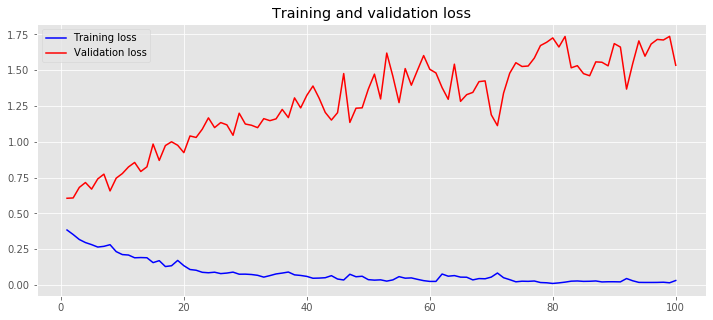

```python
plt.style.use('ggplot')

def plot_history(history):
    loss = history.history['loss']
    val_loss = history.history['val_loss']
    x = range(1, len(loss) + 1)

    plt.figure(figsize=(12, 5))
    plt.plot(x, loss, 'b', label='Training loss')
    plt.plot(x, val_loss, 'r', label='Validation loss')
    plt.title('Training and validation loss')
    plt.legend()
    plt.show()


plot_history(final_CNN)
```